# Toronto Shelter Usage During the 2020 Covid Pandemic

Ben Draskovic

2020-09-29

Abstract

Depite historically high unemployment rates in Toronto, Shelter usage is down, what does this odd trend mean for those experiencing homelessness during the Covid Pandemic? In this paper we explore the usage trends across different shelter types and attempt to grapple with the common explanation of Shelter capacity. We find that while the current explanation of shelter capacity does on first glance explain some data trends, there are trends with in the data that do not fit this narrative and need to be explored further. Our findings have implications for how this critical service may need to be supported in this trying time.

# Introduction

Based on the Canada Labor Force Survey over the past couple months the unemployment rate in Toronto has risen to 14.2% in August 2020. The highest it has been since 2001 (Stats Canada 2020). This largely stems from the pandemic the country is currently grappling with and the large effect it has on the Toronto service sector(Gellatly 2020). However, when looking at shelter usage you find somethign interesting. Despite the normal prediction that higher unemployment would lead to an increase in the need for shelter spaces, that is not the trend that emerges in the data. During a time of unprecedented unemployment in the city the daily shelter occupancy census is showing lower and lower occupancy as we get further in to the pandemic (Toronto Shelter, Support & Housing Administration 2020).

The analysis will look into the trends captured by the Toronto Daily Shelter Occupancy Census. Specifically it will examine the overall usage overtime to display the downward trend with more detail. We will look at the number of shelters in the Toronto Shelter Network that are open and how these numbers fluctuate. Finally, this downward trend in occupation will also be broken down by the Sectors that exist with in shelter work to see if the trend is affecting each sector equally. Through this analysis we can see that the general arguement put forward in the media about capacity effecting ocupation during the pandemic may be one part of explaining the drop in shelter usage. But there is much more that needs to be explored.

This paper will begin with an outline of the dataset used and how it was collected. It will then go through a break down of the collected usage data by Shelter sector and compare this with other data sources looking at possible explanations. Finally it will end with a discussion of what next steps should be taken to better understand the state of Shelters in Toronto during this crisis. Some notable weaknesses in the data we will be working with is that there is no explanatory data outside of which sector each shelter is a part of, ie Women’s shelter, Youth Shelter, etc. Therefore it is difficult to determine why people are leaving the shelters. Is it because of a concern over Covid, the generous government supports that have been provided for the outbreak, or is it purely an issue of dwindling funding and capacity?

# The Data Set

The data set that will be used for this analysis as mentionned above is the Toronto Daily Shelter Occupancy Census. Specifically the data collected between 2020-01-01 and 2020-09-26. This survey is conducted by staff at all Toronto governement affiliated shelters. The target population of this survey is those that use shelter services in Tornto, and it’s goal is to track the overall number of people using those services on a daily basis as well as how close to capacity the system is. However, the frame of this survey, or what it actually measures, limits the amount of the target population we are able to see. It only tracks individuals who have spent the night at a shelter and are still around during the time when staff do the census count at 4am every morning. This means that individuals who use the services during the day are not tracked, and that anyone who stays the night but leaves before the 4am count for any reason is not included. Furthermore, the data for shelters specializing in Violence against Women has been removed from the data set for security reasons. Thus Torontonians who use those specific services will not be included in this survey. Additionally temporary shelters, such as hotel rooms and apartments, leased by the City of Toronto do not appear to be included in this count. This is because they are not considered permanent Shelters included in Toronto’s Shelter Network.

As for sampling, since this is a census there should be little difference between the population actually sampled and the frame. While of course, there is always some error generated by human factors. Errors that can lead to data beign inaccurate, it should be relatively robust and very close to the frame set out by the census. Examples of such errors including miscounts or misunderstnading of what data is to be included. This lack of error should be especially true since the individuals doing the census are doing it in-person and have access to the shelters where the individuals are staying. So they have a strong familiarity with the sector and a head count should not create too many opportunities for bias among the relatively large number of data collectors.

Something of note before we move forward with analysis is that unfortunately with how quickly things change durign the pandemic, Capacity figures provided by shelters have become out of date. With how quickly they have been required to adjust practices and move facilities an accurate number of capacity is not able to be provided at this time. So despite capacity appearing in the data set it is unfortunately not an accurate variable that can be used for analysis.

Diving into the data set itself we can see that it collects data on the Shelter, it’s location, the program the shelter provides, what sector it serves, the occupancy head count, the date the count was done, an id number for the entry and the old capacity figures. It also includes 2 collumns that are no longer used. A sample of the data follows bellow.

```r
head(shelter_usage) #Show the first 6 rows of data in the data set
```

```
## # A tibble: 6 x 15
##    `_id` OCCUPANCY_DATE SECTOR SHELTER_POSTAL_~ CAPACITY SHELTER_PROVINCE
##    <int> <chr>          <chr>  <chr>               <int> <chr>
## 1 4.81e6 2020-02-19T00~ Women  M8Y 1A3                40 ON
## 2 4.81e6 2020-02-19T00~ Women  M5B 1G6                 6 ON
## 3 4.81e6 2020-02-19T00~ Women  M5B 1G6                38 ON
## 4 4.81e6 2020-02-19T00~ Women  M2M 3S3                30 ON
## 5 4.81e6 2020-02-19T00~ Men    M4W 1J1                 5 ON
## 6 4.81e6 2020-02-19T00~ Men    M4W 1J1                61 ON
## # ... with 9 more variables: FACILITY_NAME <chr>, SHELTER_NAME <chr>,
## #   OCCUPANCY <int>, ORGANIZATION_NAME <chr>, SHELTER_ADDRESS <chr>,
## #   SHELTER_CITY <chr>, PROGRAM_NAME <chr>, id <lgl>, DateRange <lgl>
```

We can also see that as this is a census done by shelter staff members there are no responses that must be removed from the data set. All responses given by these professionals are appropriate for the value they are describing.

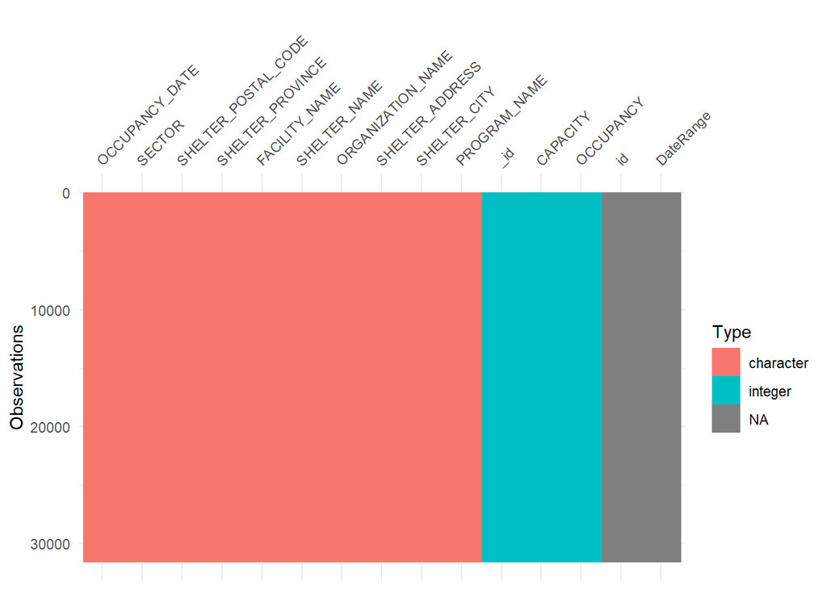

```r
visdat::vis_dat(shelter_usage) #show if there are any na responses in the data set and whta type of value is stored in each collumn
```

```r
skimr::skim(shelter_usage) #provide a brief statistical overview of the data
```

Data summary

| Name | shelter_usage |
| --- | --- |
| Number of rows | 31598 |
| Number of columns | 15 |
| _______________________ |  |
| Column type frequency: |  |
| character | 10 |
| logical | 2 |
| numeric | 3 |
| ________________________ |  |
| Group variables | None |

**Variable type: character**

| skim_variable | n_missing | complete_rate | min | max | empty | n_unique | whitespace |
| --- | --- | --- | --- | --- | --- | --- | --- |
| OCCUPANCY_DATE | 0 | 1 | 19 | 19 | 0 | 272 | 0 |
| SECTOR | 0 | 1 | 3 | 8 | 0 | 5 | 0 |
| SHELTER_POSTAL_CODE | 0 | 1 | 6 | 7 | 0 | 55 | 0 |
| SHELTER_PROVINCE | 0 | 1 | 2 | 2 | 0 | 1 | 0 |
| FACILITY_NAME | 0 | 1 | 4 | 32 | 0 | 89 | 0 |
| SHELTER_NAME | 0 | 1 | 9 | 32 | 0 | 55 | 0 |
| ORGANIZATION_NAME | 0 | 1 | 9 | 39 | 0 | 29 | 0 |
| SHELTER_ADDRESS | 0 | 1 | 13 | 32 | 0 | 55 | 0 |
| SHELTER_CITY | 0 | 1 | 7 | 11 | 0 | 4 | 0 |
| PROGRAM_NAME | 0 | 1 | 7 | 65 | 0 | 121 | 0 |

**Variable type: logical**

| skim_variable | n_missing | complete_rate | mean | count |
| --- | --- | --- | --- | --- |
| id | 31598 | 0 | NaN | : |
| DateRange | 31598 | 0 | NaN | : |

**Variable type: numeric**

| skim_variable | n_missing | complete_rate | mean | sd | p0 | p25 | p50 | p75 | p100 | hist |
| --- | --- | --- | --- | --- | --- | --- | --- | --- | --- | --- |
| _id | 0 | 1 | 4820186.50 | 9121.70 | 4804388 | 4812287 | 4820187 | 4828086 | 4835985 | ▇▇▇▇▇ |
| CAPACITY | 0 | 1 | 58.66 | 90.14 | 0 | 14 | 34 | 67 | 888 | ▇▁▁▁▁ |
| OCCUPANCY | 0 | 1 | 46.22 | 72.56 | 0 | 10 | 28 | 54 | 778 | ▇▁▁▁▁ |

Now that we have a rough idea of what has been collected, are there trends in the data?

# Analysis & Discussion

One of the major trends we can see in 2020 is a rapid decline in the number of people using shelter services on a day to day basis. This is of note as usually when unemployment increases you would expect an increase in shelter usage unless there is something preventing that increase (Toronto Shelter, Support & Housing Administration 2018). So is there something going on here?

Taking a closer look at shelter occupancy over time we se an odd shape to the decline.

## Figure 1

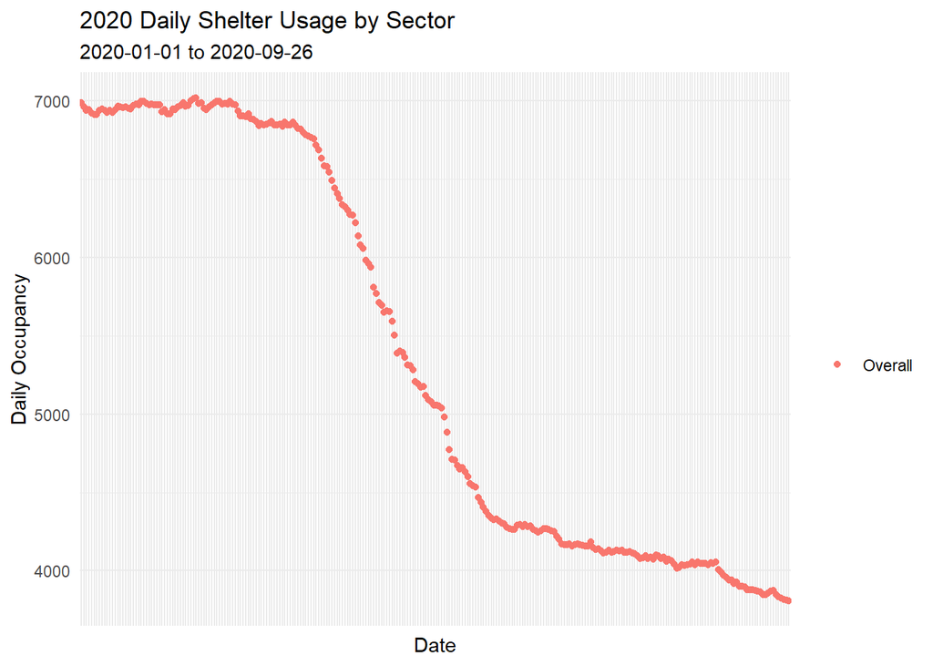

```r
daily_shelter_usage_overall <- shelter_usage %>%  #generate a new data set
  select(OCCUPANCY_DATE, SECTOR, OCCUPANCY, PROGRAM_NAME) %>% #select the collumns we wish to use
  mutate(DATE = substr(OCCUPANCY_DATE, 1, 10)) %>% #Shorten the dates to remove the time at the end of each date
  group_by(DATE) %>% #group all rows by date
  summarise(OCCUPANCY = sum(OCCUPANCY)) #Change Occupancy to be the sum of occupancy on that date
## `summarise()` ungrouping output (override with `.groups` argument)

plot1 <- daily_shelter_usage_overall %>%   # create a savable plot
  ggplot(aes( y = OCCUPANCY, x = DATE, color="Overall")) +  #use ggplot with x, y, and color defined
  geom_point() + #usign a point plot
  labs(title = "2020 Daily Shelter Usage by Sector", y = "Daily Occupancy", x = "Date", subtitle = "2020-01-01 to 2020-09-26", color="")+ #teming and titling
  theme_minimal()

plot1 +  theme(axis.text.x = element_blank()) #print the plot and remove the bottom axis labels as they are unreadable
```

Looking at the data we see a generally stable daily occupancy of around 7000 Torontonians, until we reach the end of March and the Covid Pandemic first starts to largely effect Toronto. From there we see a rapid decline of occupancy until we reach the month of June where the decline begins to tailor off.

```r
monthly_shelter_usage <- shelter_usage %>% #generate a new data set
  select(OCCUPANCY_DATE, SECTOR, OCCUPANCY, PROGRAM_NAME) %>% #select important columns
  mutate(MONTH = substr(OCCUPANCY_DATE, 6, 7)) %>% #change the extended Occupancy_date field to only include the month
  group_by(MONTH) %>% #group by this new field
  summarise(OCCUPANCY = sum(OCCUPANCY)) #Change occupancy to be the total occupancy in that month
## `summarise()` ungrouping output (override with `.groups` argument)

monthly_shelter_usage #print this table
```

```
## # A tibble: 9 x 2
##   MONTH OCCUPANCY
##   <chr>     <int>
## 1 01       215681
## 2 02       202171
## 3 03       212216
## 4 04       183679
## 5 05       154591
## 6 06       129069
## 7 07       128524
## 8 08       125836
## 9 09       108810
```

Looking at the monthly figures we largely see the same story.

Many actors in the space link this drop to changes in Capacity that are unfortunately not tracked in this data set. Based on recent news stories on shelters in the Covid crisis, one would expect a sharp decline as shelters needed to change how they were housing clients to meet new health standards. Then once this transition was done a steadying or even possibly an increase in occupation as more sites are able to be created and house individuals (Jake Kivanç 2020, Backgrounder 2020).

Instead the decline has continued just at a slowed rate even as many organizations have been able to adjust.

Perhaps this is because of individuals being moved from permanent to temporary Shelters lowerign the occupancy over time? But, if so why are these Toronto supported shelters being emptied during a time where space would theoretically be at a premium?

Also the number of individuals housed in temporary shelters is roughly 3,500 people (Backgrounder 2020). Adding that to the current number of individuals in permanent shelters would bring us back to pre-covid numbers of Torontonians in Shelters. Which would not track with the historic increase in unemployment. Furthermore in the same press release it claims that the Shelter system is housing 7000 people which is demonstrably incorrect so it is difficult to check the validity of that 3,500 number.

So is there a way with this data set to take a look at capacity? So we can confirm the hypothesis put forward by the media?

Unofrtunately no. Capacity is a value that is not reliable in this data set. We can attempt to approximate this value by looking at if there was a change in the number of shelters Torontonians were occupying during the pandemic. Hoping that if we see a large increase or decrease in these numbers we can hypothesize that there may have been a change in general Capacity as new shelters were created or pre-existing shelters had to close their doors. However, this is in no way a good measure of capacity as we do not know the size of shelters entering or exiting the network.

Having said that, seeing whether Shelters were being closed or opened during this pandemic could provide some interesting information.

## Figure 2

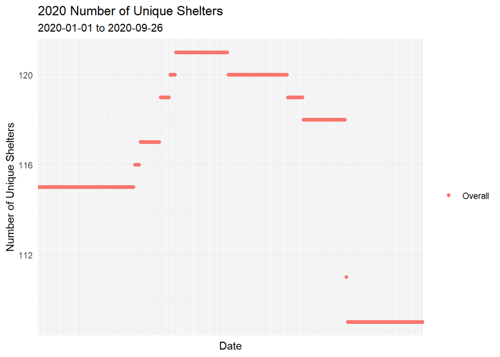

```r
number_of_unique_shelters <- shelter_usage %>% #create new data set to save in to
  mutate(DATE = substr(OCCUPANCY_DATE, 1, 10), UNIQUE_sHELTERS = 0) %>% #Shorten Occupancy_date to remove the time, create new empty column called Unique_shelters
  group_by(DATE) %>% #group by the date
  summarise(UNIQUE_SHELTERS = n_distinct(PROGRAM_NAME)) #fill Unique_shelters with a count of each distinct program name by date
## `summarise()` ungrouping output (override with `.groups` argument)

plot3 <- number_of_unique_shelters %>% #save the plot
  ggplot(aes( y = UNIQUE_SHELTERS, x = DATE, color = "Overall")) + #use gg plot to create a point plot with x, y, and colour
  geom_point() +
  labs(title = "2020 Number of Unique Shelters", y = "Number of Unique Shelters", x = "Date", subtitle = "2020-01-01 to 2020-09-26", color="")+
  theme_minimal()

plot3 +  theme(axis.text.x = element_blank()) #print plot and remove the x axis lsit of dates as illegible
```

```r
number_of_unique_shelters_monthly <- shelter_usage %>% #generate new data set
  select(OCCUPANCY_DATE, SECTOR, OCCUPANCY, PROGRAM_NAME) %>%  #select what is needed
  mutate(MONTH = substr(OCCUPANCY_DATE, 6, 7), UNIQUE_SHELTERS = 0) %>%  #add Unique_shelters and shorten Occupancy_date to only month
  group_by(MONTH) %>%  #group by month
  summarise(UNIQUE_SHELTERS = n_distinct(PROGRAM_NAME)) #fill empty Unique_shelters with number of distinct program names in a month
## `summarise()` ungrouping output (override with `.groups` argument)

number_of_unique_shelters_monthly #print this table
```

```
## # A tibble: 9 x 2
##   MONTH UNIQUE_SHELTERS
##   <chr>           <int>
## 1 01                115
## 2 02                115
## 3 03                119
## 4 04                121
## 5 05                121
## 6 06                120
## 7 07                119
## 8 08                118
## 9 09                109
```

Interestingly we can see that as the pandemic began to hit there was a small increase in Shelters open to the public. However, what is more significant is the sizable drop in permanent shelters in September. Could this be linked to the overall drop in occupancy in September we see in Figure 1?

This could also not be significant to the general occupation level. Either way it could show the perceived effects Covid has had on non-profit organizations reliant on donations. A general in flux of donations at the begin of Covid was experienced by front line organizations. However, this was followed by a slow decrease in giving over time as the Canadian Economy was affected more and more (Lasby 2020).

Another way to endeavor to check the hypothesois that Occupation is largely beign affected by Health Regulations and their effect on Capacity is by looking into occupancy in permanent shelters based upon the Sector they serve. This splitting of the data can help us see if the Sector a shelter is focusing on is acting as a confounding variable. As this would suggest either a direct relationship with capacity or that it is representing other confounding variables not included in the data set.

## Figure 3

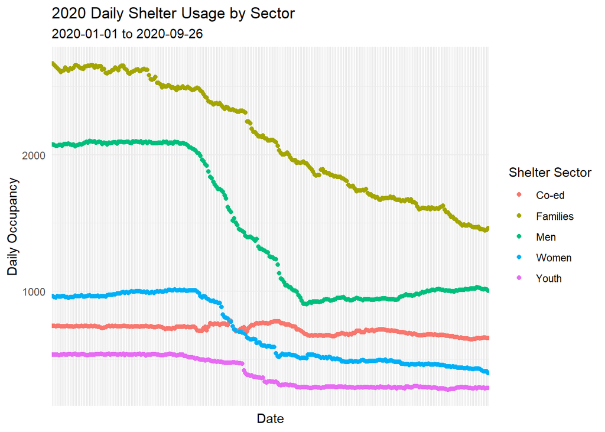

```r
daily_shelter_usage <- shelter_usage %>% #generate new data set
  select(OCCUPANCY_DATE, SECTOR, OCCUPANCY, PROGRAM_NAME) %>% #select important collumns
  mutate(DATE = substr(OCCUPANCY_DATE, 1, 10)) %>% #shorten the occupancy date removing time
  group_by(DATE, SECTOR) %>% #group by both date and sector
  summarise(OCCUPANCY = sum(OCCUPANCY)) #replace Occupancy with the sum of occupants in each type of shelter on each individual day
## `summarise()` regrouping output by 'DATE' (override with `.groups` argument)

plot2 <- daily_shelter_usage %>%  #save the plot
  ggplot(aes( y = OCCUPANCY, x = DATE, color = SECTOR)) + #use ggplot to create point plot wiht x, y, and color
  geom_point() +
  labs(title = "2020 Daily Shelter Usage by Sector", y = "Daily Occupancy", x = "Date", subtitle = "2020-01-01 to 2020-09-26", color = "Shelter Sector" )+
  theme_minimal()

plot2 +  theme(axis.text.x = element_blank()) #print plot and remove x axis labels as they are illegible
```

This graph provides another interesting view of the trend. While Sectors, like Shelters for Men and for Women, follow the curve we would predict, a sharp drop followed by a levelling out many other sectors do not.

Family shelters almost have a consistent drop through out this entire time period with out the same massive drop as new health standards were introduced. Perhaps this suggests that many of them met the health standards but have begin to slowly close for another reason?

Youth Shelters similarly do not see a big drop until well after the initial drop Male and Women shelters experienced. The rate at which occupancy is decreasing does however level out at a similar time. Does this represent a grace period before health standards kicked in for this sector? Provided to Youth shelters in order to help with moving clients? Or something entirely different?

Finally Co-ed Shelters appear to be roughly steady through out this entire period. This could suggest that do to safety requirements they must already meet they were well suited to the health needs of Covid? Or perhaps that another factor has counteracted the drop we see in all other sectors?

No matter how you look at this data it does make it appear that is not only being effected by the new health requirements and how they may have affected Shelter capacity. There appears to be at least a few different confounding variables that are effecting Shelters across different sectors.

# Weaknesses and Next Steps

As has been mentionned multiple times without knowing the capacity and percentage of capacity that is currently filled at shelters it is difficult to comment on the claims made by those in the media. The open data provided by the City of Toronto is unable to confrim or deny the general perception of capacity changes.

Also, Without qualitative accounts on the reasons people are leavign shelters it is difficult to suggest what is causign the decline. A possible positive reason for the decline is the generous Employment Insurance benefits the Federal Government is providing durign this time. This could be keeping the number of people needing Shelter services relatively stable or even be slowly decreasing it over time. As it has been shown that nearly every individual in Shelters would rather be in market or subsidized housing (Toronto Shelter, Support & Housing Administration 2018).

A possible negative effect is the perception of the dangers shelters provide to their inhabitants. Most people in the homeless population suffer from health issues that make them more supseptable to Covid, and there have been multiple outbreak in Shelters. This could lead individuals to choose to stay on the street or avoid these services at all costs even if they would like to use them in other circumstances (Perri 2020).

Furthermore without explanatory variables provided by the services themselves it is difficult to remove confounding variables that could be tied in with Capacity. How is funding related to Capacity, versus changing requirements being placed on their physical spaces, versus their ability to staff the facility?

A similair study to the Toronto Streets Needs Assessment 2018 needs to be done in order to appropriately understand how to best serve the Homeless in Toronto during this crisis (Toronto Shelter, Support & Housing Administration 2018). This would allow policy makers a better look at the population using their Shelter services. Both in shelters and currently on the streets.

However, even something as small as providing a short exit survey that all individuals leaving shelters would be asked to fill out could solve many of the initial questions asked by this paper. It could give a clear picture of the reason individuals are leaving the system even after it should have stabliized. It would also help to show some of the biigest issues they are experiencing. While this would reduce some of the simplicity of the census approach it would provide far richer data.

Furthermore, this analysis would recommend a survey that could be sent out to shelters at least on a monthly basis. This could provide better estimations of capcity than the outdated ones that are based on pre-covid numbers. It could also allow case workers and staff at shelters an opportunity to share their insights from the field as to what their individual shelters are struggling with. Espicially as we have seen a rapid decline in the number of shelters over this past month. While this would add some bias as each staff memebr would have their own view on the situation the overall data could be useful for spotting trends in the service providers.

Providing safe shelters during this trying time is integral to public health. Explaining the drop in service use and ensuring that the services are well suited to community needs can safe lives.

# Bibliography

- Sharla Gelfand (2020). opendatatoronto: Access the City of Toronto Open Data Portal. R package version 0.1.3. https://CRAN.R-project.org/package=opendatatoronto
- Wickham et al., (2019). Welcome to the tidyverse. Journal of Open Source Software, 4(43), 1686, https://doi.org/10.21105/joss.01686
- JJ Allaire and Yihui Xie and Jonathan McPherson and Javier Luraschi and Kevin Ushey and Aron Atkins and Hadley Wickham and Joe Cheng and Winston Chang and Richard Iannone (2020). rmarkdown: Dynamic Documents for R. R package version 2.3. URL https://rmarkdown.rstudio.com.
- Yihui Xie and J.J. Allaire and Garrett Grolemund (2018). R Markdown: The Definitive Guide. Chapman and Hall/CRC. ISBN 9781138359338. URL https://bookdown.org/yihui/rmarkdown.
- Elin Waring, Michael Quinn, Amelia McNamara, Eduardo Arino de la Rubia, Hao Zhu and Shannon Ellis (2020). skimr: Compact and Flexible Summaries of Data. R package version 2.1.2. https://CRAN.R-project.org/package=skimr
- Tierney N (2017). “visdat: Visualising Whole Data Frames.” *JOSS*, *2*(16), 355. doi: 10.21105/joss.00355 (URL: https://doi.org/10.21105/joss.00355), <URL: http://dx.doi.org/10.21105/joss.00355>
- Baptiste Auguie (2017). gridExtra: Miscellaneous Functions for “Grid” Graphics. R package version 2.3. https://CRAN.R-project.org/package=gridExtra
- Sam Firke (2020). janitor: Simple Tools for Examining and Cleaning Dirty Data. R package version 2.0.1. https://CRAN.R-project.org/package=janitor
- Hadley Wickham, Romain François, Lionel Henry and Kirill Müller (2020). dplyr: A Grammar of Data Manipulation. R package version 1.0.2. https://CRAN.R-project.org/package=dplyr
- R Core Team (2020). R: A language and environment for statistical computing. R Foundation for Statistical Computing, Vienna, Austria. URL https://www.R-project.org/
- Government of Canada, Statistics Canada (2020, September 03). Labour Force Survey (LFS). Retrieved from https://www23.statcan.gc.ca/imdb/p2SV.pl?Function=getSurvey&lang=en&db=imdb&adm=8&dis=2&SDDS=3701
- Gellatly, G., & McCormack, C. (2020, June 24). Recent Developments in the Canadian Economy, 2020: COVID-19, second edition. Retrieved from https://www150.statcan.gc.ca/n1/pub/11-626-x/11-626-x2020004-eng.htm
- Backgrounder - City of Toronto. (2020, August 07). City of Toronto COVID-19 Response for People Experiencing Homelessness. Retrieved from https://www.toronto.ca/news/city-of-toronto-covid-19-response-for-people-experiencing-homelessness/
- Lasby, D. (2020). Imagine Canada’s Sector Monitor: Charities & the COVID-19 Pandemic. Retrieved from https://imaginecanada.ca/sites/default/files/COVID-19 Sector Monitor Report ENGLISH_0.pdf
- Kivanç, J. (2020, September 07). Toronto considering ambitious homeless housing plan in wake of COVID-19 pandemic | CBC News. Retrieved from https://www.cbc.ca/news/canada/toronto/ontario-homeless-housing-1.5714698
- Perri, M., Dosani, N., & Hwang, S. W. (2020, June 29). COVID-19 and people experiencing homelessness: Challenges and mitigation strategies. Retrieved from https://www.cmaj.ca/content/192/26/E716.short
- Toronto Shelter, Support & Housing Administration. (2018). Street Needs Assessment 2018. Retrieved from https://www.toronto.ca/wp-content/uploads/2018/11/99be-2018-SNA-Results-Report.pdf
- Toronto Shelter, Support & Housing Administration. (2020). Daily Shelter Occupancy. Retrieved from https://open.toronto.ca/dataset/daily-shelter-occupancy/